# Chapter 3 Calculations

Dave Bosworth

3/27/2020

# Purpose

This document provides a second check on the calculations made in the Yolo Bypass Mass Balance section in Chapter 3 of the Open Water final report.

# Calculations

Load R packages necessary for this analysis:

```r
# Load packages
library(tidyverse)
library(openwaterhg)
library(knitr)
library(kableExtra)
```

## Water Balances section

Calculate percentage of each tributary’s inflow to the total inflow. This is for the entire 2017 flood event from 1/9/2017 to 5/4/2017.

```r
# Calculate the total inflow of each tributary for the entire 2017 flood event
inlet_flow <- daily_flow_data_all %>%
  filter(
    LocType == "Inlet",
    Date >= "2017-01-09",
    Date <= "2017-05-04"
  ) %>%
  group_by(StationName) %>%
  summarize(total_flow = sum(Flow)) %>%
  arrange(StationName)

# Calculate the total inflow to the Bypass
total_inflow <- sum(inlet_flow$total_flow)

# Fremont Weir percentage
fre_per_flow <- round((inlet_flow %>% slice(3) %>% pull(total_flow))/total_inflow * 100)

# Sacramento Weir percentage
sw_per_flow <- round((inlet_flow %>% slice(6) %>% pull(total_flow))/total_inflow * 100)
```

When spilling, the Fremont weir was the largest contributor of water to the Yolo Bypass accounting for an average of 75% of tributary inflows, followed by the Sacramento weir at 14%

Same as in report.

Pull out the percentage for CCSB on March 15, 2017.

```r
inlet_flow_mar15 <- daily_flow_data_se %>%
  filter(
    LocType == "Inlet",
    SamplingEvent == "Mar 15-16, 2017"
  ) %>%
  arrange(StationName)

# Calculate total inflow for that day
total_flow_mar15 <- sum(inlet_flow_mar15$Flow)

# CCSB percentage
ccsb_mar15 <- inlet_flow_mar15$Flow[1] + inlet_flow_mar15$Flow[2]
ccsb_per_flow_mar15 <- round(ccsb_mar15/total_flow_mar15 * 100)
```

On the one occasion when the Fremont weir was not overtopping (March 15, 2017), the CCSB became the dominant source (55%) of water into the Yolo Bypass

Same as in report.

Calculate percentage of SCHISM location outflow to the total outflow. This is for the entire 2017 flood event from 1/10/2017 to 5/5/2017.

```r
# Calculate the total outflow of each SCHISM location for the entire 2017 flood event
outlet_flow <- daily_flow_data_all %>%
  filter(
    Date >= "2017-01-10",
    Date <= "2017-05-05",
    LocType == "Outlet"
  ) %>%
  group_by(StationName) %>%
  summarize(total_flow = sum(Flow)) %>%
  arrange(StationName)

# Calculate the total SCHISM outflow from the Bypass
total_outflow <- sum(outlet_flow$total_flow)

# Shag Slough percentage
shag_per_flow <- round((outlet_flow %>% slice(4) %>% pull(total_flow))/total_outflow * 100)
```

Modeled water mass balances estimated that approximately 18% of the water leaves the Yolo Bypass via Shag Slough.

18% instead of 19%

```r
rm(inlet_flow_mar15, ccsb_mar15, ccsb_per_flow_mar15, fre_per_flow, shag_per_flow, sw_per_flow, total_flow_mar15, total_inflow, total_outflow)
```

## Tributary Input Loads section

Process input load data:

```r
# Filter just inlet loads for 2017
inlet_loads <- loads_calc %>%
  filter(
    Year == 2017,
    LocType == "Inlet"
  ) %>%
  select(SamplingEvent, StationName, Analyte, Load)

# Create a df of CCSB load data
ccsb_loads <- filter(inlet_loads, str_detect(StationName, "^CCSB"))

# Sum the CCSB loads
ccsb_loads_total <- ccsb_loads %>%
  group_by(SamplingEvent, Analyte) %>%
  summarize(Load = sum(Load)) %>%
  mutate(StationName = "CCSB")

# Add the summed CCSB loads to the inlet_loads df
inlet_loads <- inlet_loads %>%
  anti_join(ccsb_loads, by = "StationName") %>%
  bind_rows(ccsb_loads_total)

rm(ccsb_loads, ccsb_loads_total)

# Create tibbles of zero load values for Fremont and Sacramento Weirs and add to loads df
analytes <- unique(inlet_loads$Analyte)

fre_mar15 <- tibble(
  SamplingEvent = "Mar 15-16, 2017",
  StationName = "Fremont Weir",
  Analyte = analytes,
  Load = 0
)

sw_zeros <- tibble(
  SamplingEvent = rep(
    c(
      "Jan 31-Feb 1, 2017",
      "Mar 15-16, 2017",
      "Mar 28-29, 2017",
      "Apr 11-12, 2017",
      "Apr 25-26, 2017"
    ),
    14
  ),
  StationName = "Sac River above the Sacramento Weir",
  Analyte = rep(analytes, 5),
  Load = 0
)

inlet_loads <- bind_rows(inlet_loads, fre_mar15, sw_zeros)
rm(analytes)
```

Calculate percentage of each tributary’s input load to the total input load. This is for the all 9 sampling events during the 2017 flood event.

```r
# Calculate total inlet loads of each parameter for each sampling event
total_inlet_loads <- inlet_loads %>%
  group_by(SamplingEvent, Analyte) %>%
  summarize(total_load = sum(Load)) %>%
  ungroup()

# Calculate percentage of total load for each tributary
inlet_loads_per <- inlet_loads %>%
  left_join(total_inlet_loads) %>%
  mutate(load_per = Load/total_load * 100)

# Calculate averages of the percentages across all sampling events in 2017
inlet_loads_per_avg <- inlet_loads_per %>%
  group_by(StationName, Analyte) %>%
  summarize(avg_load_per = round(mean(load_per))) %>%
  ungroup()

# Pull out average percentages for Fremont Weir
fre_avg_per_load_uhg <- inlet_loads_per_avg %>%
  filter(
    StationName == "Fremont Weir",
    Analyte == "THg- total"
  ) %>%
  pull(avg_load_per)

fre_avg_per_load_umehg <- inlet_loads_per_avg %>%
  filter(
    StationName == "Fremont Weir",
    Analyte == "MeHg- total"
  ) %>%
  pull(avg_load_per)

fre_avg_per_load_tss <- inlet_loads_per_avg %>%
  filter(
    StationName == "Fremont Weir",
    Analyte == "TSS"
  ) %>%
  pull(avg_load_per)
```

Fremont weir was the largest contributor of water to the Yolo Bypass and, on average, was the largest contributor of uHg (65%), uMeHg (60%), and TSS (71%) to the Yolo Bypass

**These numbers are different than those in the report.**

Look at how Sacramento Weir ranks with other inputs when it was open.

```r
inlet_loads_per_sw <- inlet_loads_per %>%
  # change some of the station names
  mutate(
    StationName = case_when(
      StationName == "Knights Landing Ridge Cut" ~ "KLRC",
      StationName == "Putah Creek at Mace Blvd" ~ "Putah Creek",
      StationName == "Sac River above the Sacramento Weir" ~ "Sacramento Weir",
      TRUE ~ StationName
    )
  ) %>%
  # Convert SamplingEvent and StationName variables to factors
  conv_fact_samplingevent() %>%
  conv_fact_inlet_names() %>%
  # Filter out 4 events when the Sac Weir was open, and only include uHg, uMeHg and TSS
  filter(
    SamplingEvent %in% c(
      "Jan 11-12, 2017",
      "Jan 24-25, 2017",
      "Feb 14-15, 2017",
      "Mar 1-2, 2017"
    ),
    Analyte %in% c("THg- total", "MeHg- total", "TSS")
  ) %>%
  # Round load_per to 1 decimal place
  mutate(load_per = round(load_per, 1)) %>%
  # Remove some variables
  select(-c(Load, total_load)) %>%
  # Sort by SamplingEvent and StationName
  arrange(SamplingEvent, StationName) %>%
  # Pivot the df wider
  pivot_wider(
    names_from = StationName,
    values_from = load_per
  )

# Show a kable for each analyte
  # uHg
  inlet_loads_per_sw %>%
    filter(Analyte == "THg- total") %>%
    select(-Analyte) %>%
    kable(caption = "uHg load percentages for each input") %>%
    kable_styling("striped")
```

uHg load percentages for each input

| SamplingEvent | KLRC | CCSB | Putah Creek | Sacramento Weir | Fremont Weir |
| --- | --- | --- | --- | --- | --- |
| Jan 11-12, 2017 | 1.0 | 26.0 | 1.5 | 19.6 | 51.9 |
| Jan 24-25, 2017 | 5.0 | 23.6 | 0.1 | 3.5 | 67.9 |
| Feb 14-15, 2017 | 0.8 | 3.5 | 0.1 | 23.9 | 71.6 |
| Mar 1-2, 2017 | 2.3 | 5.0 | 2.3 | 40.0 | 50.5 |

```r
  # uMeHg
  inlet_loads_per_sw %>%
    filter(Analyte == "MeHg- total") %>%
    select(-Analyte) %>%
    kable(caption = "uMeHg load percentages for each input") %>%
    kable_styling("striped")
```

uMeHg load percentages for each input

| SamplingEvent | KLRC | CCSB | Putah Creek | Sacramento Weir | Fremont Weir |
| --- | --- | --- | --- | --- | --- |
| Jan 11-12, 2017 | 0.9 | 9.0 | 0.9 | 20.1 | 69.2 |
| Jan 24-25, 2017 | 9.9 | 11.1 | 0.1 | 4.2 | 74.7 |
| Feb 14-15, 2017 | 7.0 | 5.3 | 0.4 | 15.8 | 71.5 |
| Mar 1-2, 2017 | 15.7 | 7.2 | 5.0 | 26.1 | 46.0 |

```r
  # TSS
  inlet_loads_per_sw %>%
    filter(Analyte == "TSS") %>%
    select(-Analyte) %>%
    kable(caption = "TSS load percentages for each input") %>%
    kable_styling("striped")
```

TSS load percentages for each input

| SamplingEvent | KLRC | CCSB | Putah Creek | Sacramento Weir | Fremont Weir |
| --- | --- | --- | --- | --- | --- |
| Jan 11-12, 2017 | 2.3 | 18.4 | 2.4 | 11.6 | 65.2 |
| Jan 24-25, 2017 | 7.5 | 12.0 | 0.1 | 1.2 | 79.2 |
| Feb 14-15, 2017 | 0.9 | 2.0 | 0.1 | 17.9 | 79.2 |
| Mar 1-2, 2017 | 3.8 | 4.3 | 2.0 | 24.7 | 65.2 |

Of the 4 events when the Sacramento weir was open, it was the second largest contributor of uMeHg for 3 events and of uHg and TSS for 2 events.

Check how the tributary contributions to input loads correspond to their contributions to input flow. Rank of 1 is the highest contributor, and 5 is the lowest. If there is good correspondence, most of the load and flow ranks would be the same. The following plot shows this information.

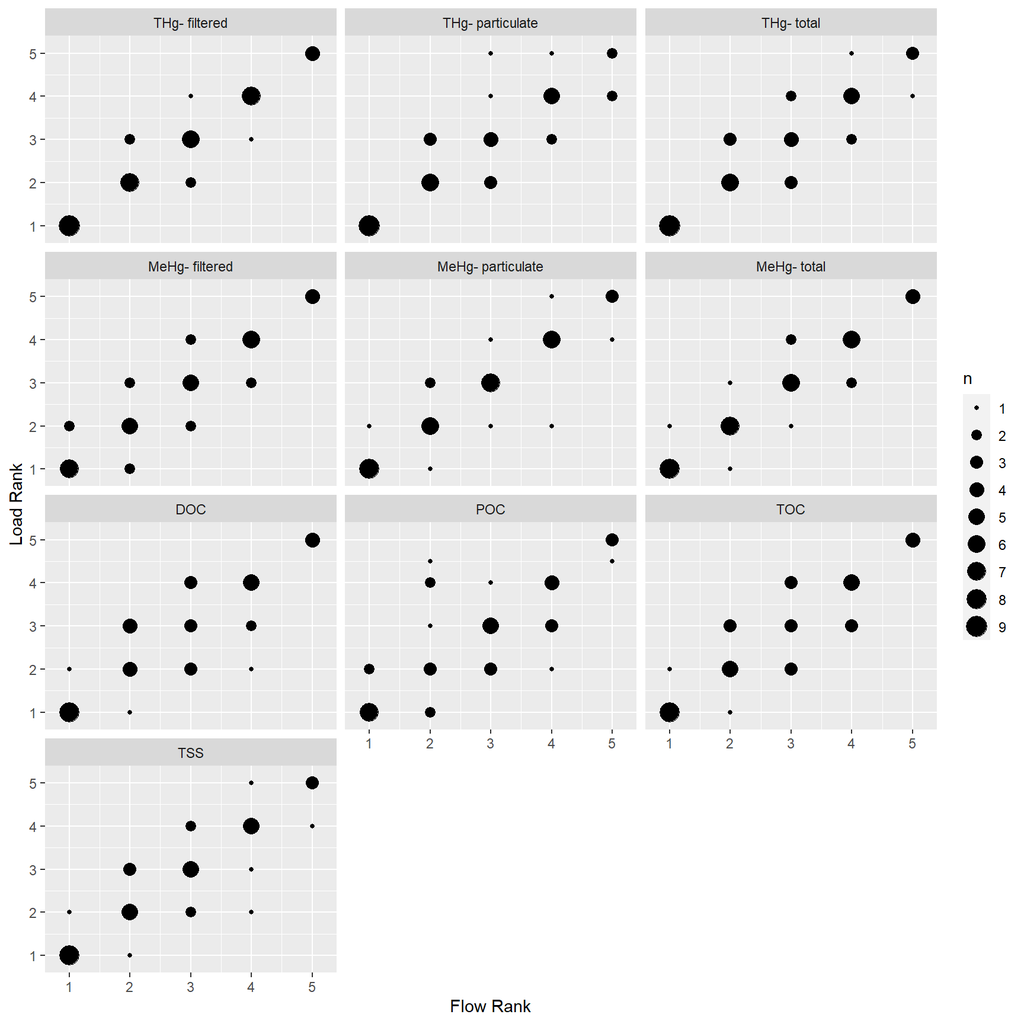

```r
# Filter just inlet flows for 2017
inlet_flow_se <- daily_flow_data_se %>%
  filter(
    Year == 2017,
    LocType == "Inlet"
  ) %>%
  select(-c(Year, LocType))

# Create a df of CCSB flow data
ccsb_flow <- filter(inlet_flow_se, str_detect(StationName, "^CCSB"))

# Sum the CCSB flows
ccsb_flow_total <- ccsb_flow %>%
  group_by(SamplingEvent) %>%
  summarize(Flow = sum(Flow)) %>%
  mutate(StationName = "CCSB")

# Add the summed CCSB flows to the inlet_flow_se df
inlet_flow_se <- inlet_flow_se %>%
  anti_join(ccsb_flow, by = "StationName") %>%
  bind_rows(ccsb_flow_total)

rm(ccsb_flow, ccsb_flow_total)

# Rank flows for each sampling event
inlet_flow_se_rank <- inlet_flow_se %>%
  filter(Flow != 0) %>%
  group_by(SamplingEvent) %>%
  mutate(flow_rank = rank(desc(Flow), ties.method = "average")) %>%
  ungroup() %>%
  select(-Flow)

# Rank loads for each sampling event and analyte
inlet_loads_rank <- inlet_loads %>%
  # Remove added zeros for events when the weirs weren't spilling
  anti_join(fre_mar15) %>%
  anti_join(sw_zeros) %>%
  group_by(SamplingEvent, Analyte) %>%
  mutate(load_rank = rank(desc(Load), ties.method = "average")) %>%
  ungroup() %>%
  select(-Load)

# Join flow and load ranks together
inlet_flow_load_ranks <- left_join(inlet_loads_rank, inlet_flow_se_rank) %>%
  # Only include parameters we are interested in
  filter(str_detect(Analyte, "^THg|^MeHg|OC$|TSS"))

# Apply plot order to analytes
analytes <- sort(unique(inlet_flow_load_ranks$Analyte))
analytes_order <- analytes[c(6:8,2:4,1,5,9,10)]
inlet_flow_load_ranks <- inlet_flow_load_ranks %>%
  mutate(Analyte = factor(Analyte, levels = analytes_order))

# Plot ranks
inlet_flow_load_ranks %>%
  ggplot(aes(x = flow_rank, y = load_rank)) +
  geom_count() +
  facet_wrap(
    vars(Analyte),
    ncol = 3
  ) +
  scale_size(breaks = seq(1, 9, by = 1)) +
  xlab("Flow Rank") +
  ylab("Load Rank") +
  scale_x_continuous(expand = expansion(mult = c(0.1, 0.1))) +
  scale_y_continuous(expand = expansion(mult = c(0.1, 0.1)))
```

Check numbers in Table 3-2. Averages and Standard deviations:

```r
# Calculate averages and standard deviations of each input and analyte
inlet_loads_avg <- inlet_loads %>%
  group_by(StationName, Analyte) %>%
  summarize(
    avg_load = mean(Load),
    stdev = sd(Load)
  ) %>%
  ungroup()

# Calculate averages and standard deviations of total input for each analyte
total_inlet_loads_avg <- total_inlet_loads %>%
  group_by(Analyte) %>%
  summarize(
    avg_load = mean(total_load),
    stdev = sd(total_load)
  ) %>%
  mutate(StationName = "Total")

# Bind total inlet loads to inlet loads df for kables
inlet_loads_avg <- bind_rows(inlet_loads_avg, total_inlet_loads_avg)

# Show a kable for each analyte
  # uHg
  inlet_loads_avg %>%
    filter(Analyte == "THg- total") %>%
    select(-Analyte) %>%
    mutate(
      avg_load = signif(avg_load, 3),
      stdev = signif(stdev, 3)
    ) %>%
    kable(caption = "uHg loads for each input") %>%
    kable_styling("striped")
```

uHg loads for each input

| StationName | avg_load | stdev |
| --- | --- | --- |
| CCSB | 571.0 | 1200.0 |
| Fremont Weir | 2090.0 | 2660.0 |
| Knights Landing Ridge Cut | 59.2 | 64.6 |
| Putah Creek at Mace Blvd | 39.8 | 66.6 |
| Sac River above the Sacramento Weir | 694.0 | 1070.0 |
| Total | 3460.0 | 4770.0 |

```r
  # uMeHg
  inlet_loads_avg %>%
    filter(Analyte == "MeHg- total") %>%
    select(-Analyte) %>%
    mutate(
      avg_load = round(avg_load, 1),
      stdev = round(stdev, 1)
    ) %>%
    kable(caption = "uMeHg loads for each input") %>%
    kable_styling("striped")
```

uMeHg loads for each input

| StationName | avg_load | stdev |
| --- | --- | --- |
| CCSB | 1.9 | 1.7 |
| Fremont Weir | 14.4 | 16.2 |
| Knights Landing Ridge Cut | 1.7 | 1.6 |
| Putah Creek at Mace Blvd | 0.4 | 0.4 |
| Sac River above the Sacramento Weir | 3.3 | 4.9 |
| Total | 21.7 | 22.9 |

A few numbers in Table 3-2 were incorrect. Corrected them in the report.

Check numbers in Table 3-2. Percentages of the total load in the particulate fraction:

```r
# Create df to be used to calculate percentages in the particulate fraction
inlet_loads_hg_frac <- inlet_loads %>%
  filter(
    str_detect(Analyte, "^MeHg|^THg"),
    Load != 0
  ) %>%
  separate(Analyte, into = c("Analyte", "Fraction"), sep = "- ") %>%
  filter(Fraction != "filtered") %>%
  pivot_wider(names_from = Fraction, values_from = Load)

# Calculate average percentages for each inlet
inlet_loads_part_avg <- inlet_loads_hg_frac %>%
  mutate(per_part = particulate/total * 100) %>%
  group_by(StationName, Analyte) %>%
  summarize(avg_per_part = round(mean(per_part))) %>%
  ungroup()

# Calculate average percentages for total inputs
inlet_loads_part_avg_total <- inlet_loads_hg_frac %>%
  group_by(SamplingEvent, Analyte) %>%
  summarize(
    part_sum = sum(particulate),
    total_sum = sum(total)
  ) %>%
  ungroup() %>%
  mutate(per_part = part_sum/total_sum * 100) %>%
  group_by(Analyte) %>%
  summarize(avg_per_part = round(mean(per_part))) %>%
  ungroup() %>%
  mutate(StationName = "Total")

# Bind df's together for kables
inlet_loads_part_avg <- bind_rows(inlet_loads_part_avg, inlet_loads_part_avg_total)

# Show a kable for each analyte
  # uHg
  inlet_loads_part_avg %>%
    filter(Analyte == "THg") %>%
    select(-Analyte) %>%
    kable(caption = "Hg- Percent in the particulate fraction for each input") %>%
    kable_styling("striped")
```

Hg- Percent in the particulate fraction for each input

| StationName | avg_per_part |
| --- | --- |
| CCSB | 84 |
| Fremont Weir | 81 |
| Knights Landing Ridge Cut | 75 |
| Putah Creek at Mace Blvd | 81 |
| Sac River above the Sacramento Weir | 87 |
| Total | 81 |

```r
  # uMeHg
  inlet_loads_part_avg %>%
    filter(Analyte == "MeHg") %>%
    select(-Analyte) %>%
    kable(caption = "MeHg- Percent in the particulate fraction for each input") %>%
    kable_styling("striped")
```

MeHg- Percent in the particulate fraction for each input

| StationName | avg_per_part |
| --- | --- |
| CCSB | 66 |
| Fremont Weir | 62 |
| Knights Landing Ridge Cut | 49 |
| Putah Creek at Mace Blvd | 63 |
| Sac River above the Sacramento Weir | 64 |
| Total | 61 |

A few differences in the inlet percentages probably due to rounding differences. **Total percentages were different than those in Table 3-2.**

## Net Loads section

Check numbers in Table 3-3.

```r
# Sum input and output loads for each sampling event
total_loads <- loads_calc %>%
  filter(
    Year == 2017,
    str_detect(Analyte, "^THg|^MeHg|OC$|TSS")
  ) %>%
  group_by(SamplingEvent, Analyte, LocType) %>%
  summarize(total_load = sum(Load)) %>%
  ungroup()

# Calculate averages and stdev for input and output (Stairsteps) loads
total_loads_summ <- total_loads %>%
  filter(LocType != "Below Liberty") %>%
  group_by(Analyte, LocType) %>%
  summarize(
    avg_load = signif(mean(total_load), 3),
    stdev_load = signif(sd(total_load), 3)
  ) %>%
  ungroup()

# Show a kable for each LocType
  # Input
  total_loads_summ %>%
    filter(LocType == "Inlet") %>%
    select(-LocType) %>%
    kable(caption = "Input Loads- Average and Std Deviations") %>%
    kable_styling("striped")
```

Input Loads- Average and Std Deviations

| Analyte | avg_load | stdev_load |
| --- | --- | --- |
| DOC | 419.00 | 468.00 |
| MeHg- filtered | 7.78 | 7.37 |
| MeHg- particulate | 13.90 | 15.70 |
| MeHg- total | 21.70 | 22.90 |
| POC | 119.00 | 207.00 |
| THg- filtered | 447.00 | 542.00 |
| THg- particulate | 3010.00 | 4230.00 |
| THg- total | 3460.00 | 4770.00 |
| TOC | 539.00 | 654.00 |
| TSS | 20900.00 | 28000.00 |

```r
  # Output
  total_loads_summ %>%
    filter(LocType == "Outlet") %>%
    select(-LocType) %>%
    kable(caption = "Output Loads- Average and Std Deviations") %>%
    kable_styling("striped")
```

Output Loads- Average and Std Deviations

| Analyte | avg_load | stdev_load |
| --- | --- | --- |
| DOC | 429.0 | 451.0 |
| MeHg- filtered | 13.1 | 10.4 |
| MeHg- particulate | 22.5 | 18.5 |
| MeHg- total | 35.5 | 28.7 |
| POC | 107.0 | 181.0 |
| THg- filtered | 444.0 | 484.0 |
| THg- particulate | 2690.0 | 3820.0 |
| THg- total | 3140.0 | 4290.0 |
| TOC | 536.0 | 618.0 |
| TSS | 13800.0 | 17800.0 |

```r
# Calculate averages and stdev for net loads
net_loads_summ <- total_loads %>%
  pivot_wider(names_from = LocType, values_from = total_load) %>%
  rename(below_liberty = "Below Liberty") %>%
  # Calculate net loads for each reach
  mutate(
    upper = Outlet - Inlet,
    lower = below_liberty - Outlet,
    entire = below_liberty - Inlet
  ) %>%
  select(-c(Inlet:below_liberty)) %>%
  pivot_longer(
    cols = upper:entire,
    names_to = "reach",
    values_to = "net_load"
  ) %>%
  filter(!is.na(net_load)) %>%
  group_by(Analyte, reach) %>%
  summarize(
    avg_net_load = signif(mean(net_load), 3),
    stdev_net_load = signif(sd(net_load), 3)
  ) %>%
  ungroup()

# Show a kable for each reach
  # Upper reach
  net_loads_summ %>%
    filter(reach == "upper") %>%
    select(-reach) %>%
    kable(caption = "Net Load- Upper Reach (Stairsteps - Input)") %>%
    kable_styling("striped")
```

Net Load- Upper Reach (Stairsteps - Input)

| Analyte | avg_net_load | stdev_net_load |
| --- | --- | --- |
| DOC | 9.33 | 51.50 |
| MeHg- filtered | 5.29 | 3.32 |
| MeHg- particulate | 8.54 | 5.86 |
| MeHg- total | 13.80 | 8.23 |
| POC | -12.10 | 27.70 |
| THg- filtered | -2.91 | 115.00 |
| THg- particulate | -318.00 | 486.00 |
| THg- total | -322.00 | 532.00 |
| TOC | -2.75 | 63.40 |
| TSS | -7120.00 | 10700.00 |

```r
  # Lower reach
  net_loads_summ %>%
    filter(reach == "lower") %>%
    select(-reach) %>%
    kable(caption = "Net Load- Lower Reach (Below Liberty - Stairsteps)") %>%
    kable_styling("striped")
```

Net Load- Lower Reach (Below Liberty - Stairsteps)

| Analyte | avg_net_load | stdev_net_load |
| --- | --- | --- |
| DOC | 34.400 | 70.1 |
| MeHg- filtered | 3.060 | 4.3 |
| MeHg- particulate | 0.548 | 11.7 |
| MeHg- total | 3.610 | 12.2 |
| POC | 44.000 | 98.6 |
| THg- filtered | 22.900 | 115.0 |
| THg- particulate | 165.000 | 693.0 |
| THg- total | 188.000 | 794.0 |
| TOC | 78.400 | 144.0 |
| TSS | 4140.000 | 10200.0 |

```r
  # Entire Bypass
  net_loads_summ %>%
    filter(reach == "entire") %>%
    select(-reach) %>%
    kable(caption = "Net Load- Entire Bypass (Below Liberty - Input)") %>%
    kable_styling("striped")
```

Net Load- Entire Bypass (Below Liberty - Input)

| Analyte | avg_net_load | stdev_net_load |
| --- | --- | --- |
| DOC | 41.50 | 45.90 |
| MeHg- filtered | 8.63 | 6.95 |
| MeHg- particulate | 9.28 | 14.20 |
| MeHg- total | 17.90 | 18.50 |
| POC | 30.00 | 73.70 |
| THg- filtered | 19.40 | 86.90 |
| THg- particulate | -193.00 | 504.00 |
| THg- total | -174.00 | 546.00 |
| TOC | 71.50 | 97.00 |
| TSS | -3820.00 | 3380.00 |

A few minor differences in Table 3-3 probably due to rounding differences.

Calculate average export of uMeHg to the Delta from the entire Yolo Bypass

```r
mehg_export_entire <- total_loads %>%
  filter(
    Analyte == "MeHg- total",
    LocType == "Below Liberty"
  )

# Calculate average export
mehg_export_entire_avg <- signif(mean(mehg_export_entire$total_load), 3)

# Calculate std deviation of export
mehg_export_entire_stdev <- signif(sd(mehg_export_entire$total_load), 3)
```

The lower reach added an additional 3.6 ± 12.2 g/day to the overall average export to the Delta of 41.9 ± 40.8 g/day of uMeHg.